# Informe Anual del Estado Académico

Análisis de Estudiantes de Carreras de Grado - Facultad Regional San Nicolás

Autor/a

Secretaría Académica - María Guadalupe Salguero

Fecha de publicación

8/12/24

# 1 Introducción

A través de este análisis, se busca proporcionar una visión integral del estado académico, identificar tendencias relevantes, y destacar posibles áreas de mejora en la gestión académica de la especialidad.

Este informe está orientado a apoyar la toma de decisiones estratégicas para el fortalecimiento de la calidad educativa y el seguimiento de los estudiantes.

# 2 Materiales y Métodos

### 2.0.2 Herramientas Utilizadas

El análisis se realizó en R utilizando las siguientes librerías:

*Librerías y Propósitos*

- `readxl:` Leer archivos Excel (.xlsx, .xls).
- `readr:` Importar y exportar archivos de texto (.csv, .tsv).
- `dplyr:` Manipulación y transformación de datos.
- `ggplot2:` Crear gráficos y visualizaciones personalizadas.
- `tidyr:` Reestructurar y organizar datos (de ancho a largo y viceversa).
- `janitor:` Limpieza y preprocesamiento de datos.
- `knitr:` Generar reportes dinámicos en HTML, PDF o Word.
- `kableExtra:` Mejorar el formato y estilo de tablas en reportes.
- `glue:` Construcción de cadenas de texto dinámicas.

**Código**

```r
# Importar librerias
library(readxl)
library(readr)
library(dplyr)
library(ggplot2)
library(tidyr)
library(janitor)
library(knitr)
library(kableExtra)
library(glue)
```

### 2.0.3 **Procedimiento**

#### 2.0.3.1 **Selección de Datos**

Se exportaron del sistema dos tablas en formato Excel:

1. **Alumnos**: Contiene información personal de los estudiantes de la Universidad.
2. **Análisis Académico**: Incluye datos académicos detallados de los estudiantes a lo largo de los años.

Ambas tablas fueron importadas a R utilizando la librería `readxl` para su posterior procesamiento y análisis.

#### 2.0.3.2 **Limpieza de Datos**

La limpieza de los datos se realizó de manera exhaustiva en el script **`limpieza.R`**, siguiendo las siguientes etapas:

1. **Corrección de Inconsistencias**:
   - Se corrigieron errores en los nombres de las columnas para mantener una nomenclatura uniforme.
   - Se unificaron los formatos de datos, como fechas, nombres y codificaciones.
2. **Eliminación de Datos Duplicados e Inconsistentes**:
   - Se eliminaron registros duplicados y valores inconsistentes que podían afectar la calidad del análisis.

Este proceso garantiza que los datos sean precisos, homogéneos y adecuados para su análisis posterior.

#### 2.0.3.3 **Carga de datos consolidados**

Se realizó la carga de datos obtenidos en el archivo **`limpieza.R`**.

**Código**

```r
# Cargar datos
data <- read_csv("data_clean/data_combinada.csv")
data <- filter(data, especialidad == params$especialidad)
```

# 3 Exploración General

En esta sección se presenta un análisis descriptivo general de la especialidad seleccionada, abordando tendencias clave como el número de ingresantes, graduados y estudiantes activos por año, así como distribuciones por género, tipo de escuela técnica y estado académico. Estos análisis proporcionan una visión integral del estado de la especialidad a lo largo de los años.

## 3.1 Ingresantes por Año

El análisis de ingresantes permite observar las tendencias en el número de estudiantes que se incorporan a la especialidad cada año, desglosado por género.

**Código**

```r
# Agrupar ingresantes por cohorte y género
ingresantes_anio_genero <- data %>%
  distinct(legajo, cohorte, sexo) %>%
  group_by(cohorte, sexo) %>%
  summarise(total = n(), .groups = "drop")

# Convertir la tabla a formato ancho con columnas por género y cohorte
ingresantes_anio_genero_wide <- ingresantes_anio_genero %>%
  pivot_wider(names_from = c(cohorte), values_from = total, values_fill = 0)

# Mostrar la tabla
kable(ingresantes_anio_genero_wide, caption = "Cantidad de Ingresantes por Género y Año (Columnas por Año)") %>%
  kable_styling(full_width = FALSE, position = "right")
```

Cantidad de Ingresantes por Género y Año (Columnas por Año)

| sexo | 2001 | 2002 | 2003 | 2004 | 2005 | 2006 | 2007 | 2008 | 2009 | 2010 | 2011 | 2012 | 2013 | 2014 | 2015 | 2016 | 2017 | 2018 | 2019 | 2020 | 2021 | 2022 | 2023 | 2024 |
| --- | --- | --- | --- | --- | --- | --- | --- | --- | --- | --- | --- | --- | --- | --- | --- | --- | --- | --- | --- | --- | --- | --- | --- | --- |
| Femenino | 27 | 33 | 32 | 21 | 18 | 25 | 17 | 33 | 27 | 17 | 17 | 23 | 22 | 15 | 27 | 28 | 22 | 27 | 32 | 24 | 31 | 28 | 28 | 40 |
| Masculino | 78 | 93 | 68 | 53 | 52 | 55 | 39 | 39 | 53 | 44 | 36 | 29 | 40 | 36 | 57 | 33 | 40 | 30 | 28 | 44 | 33 | 20 | 33 | 44 |
| NA | 7 | 21 | 4 | 6 | 7 | 10 | 5 | 3 | 4 | 6 | 8 | 5 | 7 | 6 | 9 | 9 | 2 | 2 | 3 | 1 | 1 | 1 | 3 | 0 |

**Código**

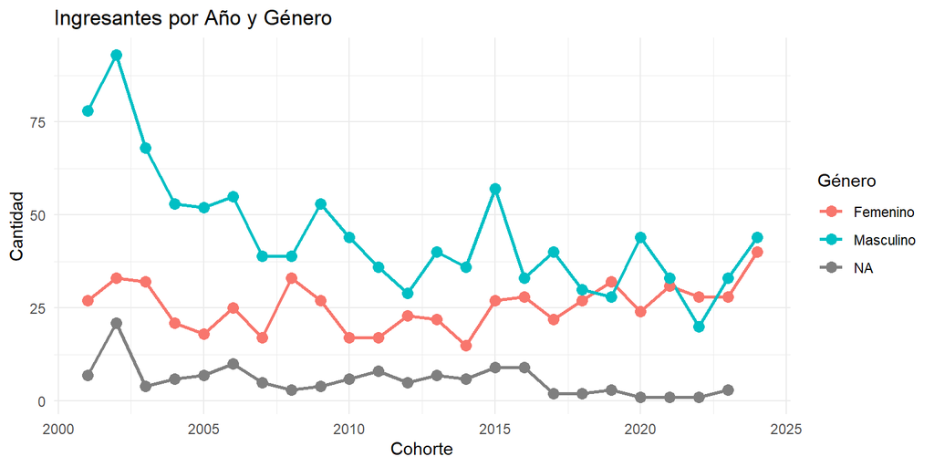

```r
# Gráfico para comparar por género
ggplot(ingresantes_anio_genero, aes(x = cohorte, y = total, color = sexo, group = sexo)) +
  geom_line(size = 1) +
  geom_point(size = 3) +
  theme_minimal() +
  labs(title = "Ingresantes por Año y Género", x = "Cohorte", y = "Cantidad", color = "Género")
```

La tabla resume la cantidad de ingresantes anuales, diferenciados por género. El gráfico de líneas facilita la comparación visual de las tendencias por género a lo largo de los años, identificando patrones de crecimiento, estabilidad o disminución.

### 3.1.1 Graduados por Año

Este análisis identifica la cantidad de estudiantes que completaron su formación en cada cohorte, desglosado por género. Se utiliza la materia con código 550 como indicador del estado de graduación.

**Código**

```r
# Agrupar graduados por cohorte y género
graduados_anio_genero <- data %>%
  filter(cod_materia == 550 & aprobado == "Aprobado") %>%
  distinct(legajo, cohorte, sexo) %>%
  group_by(cohorte, sexo) %>%
  summarise(total = n(), .groups = "drop")

# Convertir la tabla a formato ancho con columnas por género y cohorte
graduados_anio_genero_wide <- graduados_anio_genero %>%
  pivot_wider(names_from = c(cohorte), values_from = total, values_fill = 0)

# Mostrar la tabla
kable(graduados_anio_genero_wide, caption = "Cantidad de Graduados por Género y Año (Columnas por Año)") %>%
  kable_styling(full_width = FALSE, position = "right")
```

Cantidad de Graduados por Género y Año (Columnas por Año)

| sexo | 2001 | 2002 | 2003 | 2004 | 2005 | 2006 | 2007 | 2008 | 2009 | 2010 | 2011 | 2012 | 2013 | 2015 | 2016 | 2017 |
| --- | --- | --- | --- | --- | --- | --- | --- | --- | --- | --- | --- | --- | --- | --- | --- | --- |
| Femenino | 2 | 0 | 1 | 0 | 2 | 3 | 1 | 2 | 0 | 0 | 2 | 1 | 1 | 1 | 7 | 0 |
| Masculino | 8 | 3 | 1 | 1 | 1 | 3 | 3 | 3 | 2 | 1 | 4 | 2 | 1 | 0 | 1 | 4 |

**Código**

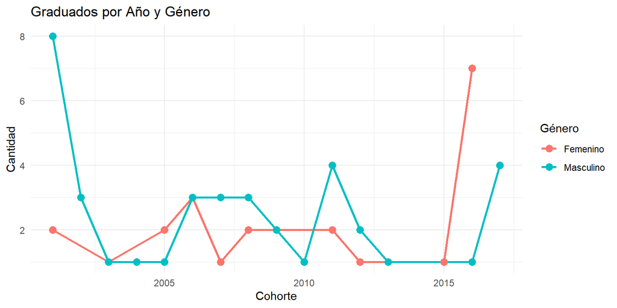

```r
# Gráfico para comparar graduados por género
ggplot(graduados_anio_genero, aes(x = cohorte, y = total, color = sexo, group = sexo)) +
  geom_line(size = 1) +
  geom_point(size = 3) +
  theme_minimal() +
  labs(title = "Graduados por Año y Género", x = "Cohorte", y = "Cantidad", color = "Género")
```

Este análisis permite medir la eficiencia del proceso educativo y detectar posibles disparidades entre géneros.

### 3.1.2 Personas Activas por Año

Se evalúa la cantidad de estudiantes que permanecen activos en la especialidad cada año, desglosado por género.

**Código**

```r
personas_activas_genero <- data %>%
  distinct(legajo, año, sexo) %>%
  group_by(año, sexo) %>%
  summarise(total = n(), .groups = "drop")

# Convertir la tabla a formato ancho con columnas por género y cohorte
personas_activas_genero_wide <- personas_activas_genero %>%
  pivot_wider(names_from = c(año), values_from = total, values_fill = 0)

# Mostrar la tabla con el título alineado a la izquierda
kable(personas_activas_genero_wide, caption = "Cantidad de Personas Activas por Género y Año (Columnas por Año)") %>%
  kable_styling(full_width = FALSE, position = "right")
```

Cantidad de Personas Activas por Género y Año (Columnas por Año)

| sexo | 1999 | 2001 | 2002 | 2003 | 2004 | 2005 | 2006 | 2007 | 2008 | 2009 | 2010 | 2011 | 2012 | 2013 | 2014 | 2015 | 2016 | 2017 | 2018 | 2019 | 2020 | 2021 | 2022 | 2023 | 2024 |
| --- | --- | --- | --- | --- | --- | --- | --- | --- | --- | --- | --- | --- | --- | --- | --- | --- | --- | --- | --- | --- | --- | --- | --- | --- | --- |
| Masculino | 1 | 58 | 153 | 161 | 174 | 168 | 159 | 150 | 151 | 159 | 147 | 139 | 128 | 132 | 140 | 148 | 149 | 149 | 153 | 145 | 154 | 159 | 119 | 129 | 166 |
| Femenino | 0 | 22 | 50 | 65 | 70 | 66 | 72 | 67 | 71 | 90 | 74 | 81 | 82 | 74 | 82 | 83 | 91 | 107 | 120 | 135 | 141 | 146 | 128 | 140 | 157 |
| NA | 0 | 1 | 22 | 14 | 14 | 12 | 10 | 11 | 9 | 11 | 9 | 13 | 7 | 13 | 7 | 3 | 5 | 11 | 3 | 6 | 6 | 3 | 3 | 3 | 0 |

**Código**

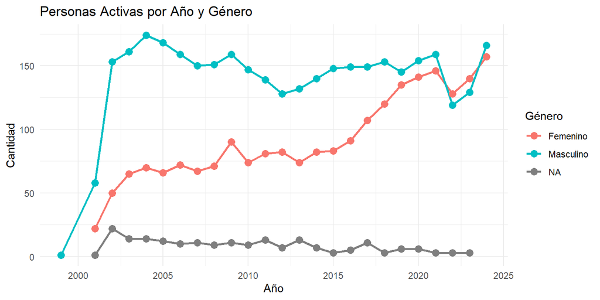

```r
# Graficar personas activas por género
ggplot(personas_activas_genero, aes(x = año, y = total, color = sexo, group = sexo)) +
  geom_line(size = 1) +
  geom_point(size = 3) +
  theme_minimal() +
  labs(title = "Personas Activas por Año y Género", x = "Año", y = "Cantidad", color = "Género")
```

Este análisis es crucial para identificar tasas de retención y detectar posibles puntos de fuga o abandono a lo largo de los años. Las tendencias divergentes entre géneros pueden revelar necesidades específicas de apoyo académico.

### 3.1.3 Distribución por género

Se analiza la composición general de la especialidad en términos de género.

**Código**

```r
# Distribución por género
distribucion_genero <- data %>%
  distinct(legajo, sexo) %>%
  group_by(sexo) %>%
  summarise(total = n(), .groups = "drop")

# Tabla
kable(distribucion_genero, caption = "Distribución de Legajos por Género") %>%
  kable_styling(full_width = FALSE)
```

Distribución de Legajos por Género

| sexo | total |
| --- | --- |
| Femenino | 614 |
| Masculino | 1077 |
| NA | 130 |

**Código**

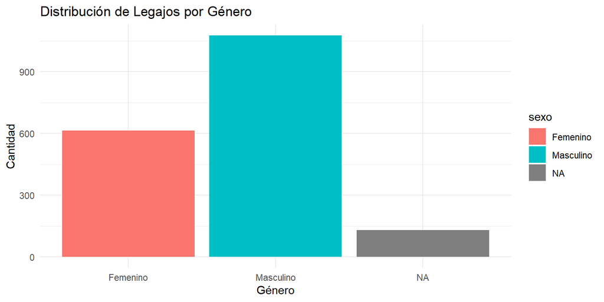

```r
# Gráfico
ggplot(distribucion_genero, aes(x = sexo, y = total, fill = sexo)) +
  geom_bar(stat = "identity") +
  theme_minimal() +
  labs(title = "Distribución de Legajos por Género", x = "Género", y = "Cantidad")
```

Este análisis proporciona un indicador de inclusión y diversidad en la especialidad. Sabiendo que la Universidad tiene una política activa de equidad de género, este indicador permite evaluar el impacto de dichas iniciativas.

### 3.1.4 Distribución de Legajos por Tipo de Escuela Técnica

Este análisis examina el tipo de formación técnica de los estudiantes al ingresar a la especialidad.

**Código**

```r
# Distribución por tipo de escuela técnica
distribucion_escuela <- data %>%
  distinct(legajo, especialidad_secundario) %>%
  group_by(especialidad_secundario) %>%
  summarise(total = n(), .groups = "drop") %>%
  arrange(desc(total))

# Tabla
kable(distribucion_escuela, caption = "Distribución de Legajos por Tipo de Escuela Técnica") %>%
  kable_styling(full_width = FALSE)
```

Distribución de Legajos por Tipo de Escuela Técnica

| especialidad_secundario | total |
| --- | --- |
| No Técnico | 1012 |
| Técnico | 679 |
| NA | 130 |

**Código**

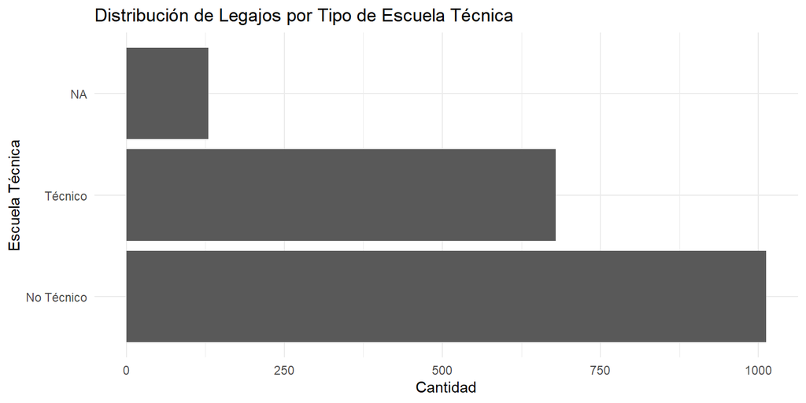

```r
# Gráfico
ggplot(distribucion_escuela, aes(x = reorder(especialidad_secundario, -total), y = total)) +
  geom_bar(stat = "identity") +
  coord_flip() +
  theme_minimal() +
  labs(title = "Distribución de Legajos por Tipo de Escuela Técnica", x = "Escuela Técnica", y = "Cantidad")
```

Proporciona información sobre los antecedentes formativos de los estudiantes, lo que puede influir en su desempeño en materias específicas. La distribución desigual entre tipos de escuelas técnicas puede guiar estrategias de nivelación y apoyo.

### 3.1.5 Distribución de Legajos por Estado

Se presenta un desglose de los estados académicos de los estudiantes, como en curso, recursante o egresado.

**Código**

```r
# Distribución por estado
distribucion_estado <- data %>%
  distinct(legajo, estado_alumno) %>%
  group_by(estado_alumno) %>%
  summarise(total = n(), .groups = "drop")

# Tabla
kable(distribucion_estado, caption = "Distribución de Legajos por Estado Académico") %>%
  kable_styling(full_width = FALSE)
```

Distribución de Legajos por Estado Académico

| estado_alumno | total |
| --- | --- |
| Activo | 1554 |
| Aspirante a Ingreso | 72 |
| De Baja | 2 |
| Egresado | 51 |
| Pase a Facultad | 11 |
| Pase a Univers. | 1 |
| NA | 130 |

**Código**

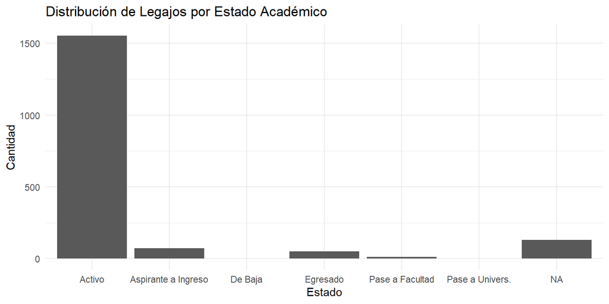

```r
# Gráfico
ggplot(distribucion_estado, aes(x = estado_alumno, y = total)) +
  geom_bar(stat = "identity") +
  theme_minimal() +
  labs(title = "Distribución de Legajos por Estado Académico", x = "Estado", y = "Cantidad")
```

Este análisis permite identificar cuántos estudiantes se encuentran en cada estado, proporcionando información clave sobre el progreso académico.

# 4 Análisis del Estado Académico - Año 2024

## 4.1 Distribución de Estados Académicos

Para el año 2024, se realizó un análisis de los estados académicos de los estudiantes. El objetivo principal es identificar la distribución de los estudiantes según su estado académico para evaluar el progreso general y detectar posibles áreas de atención.

**Código**

```r
# Filtrar por el año 2024
data_2024 <- data %>%
  filter(año == 2024)

# Resumen de estados en 2024
estado_2024 <- data_2024 %>%
  distinct(legajo, estado) %>%
  group_by(estado) %>%
  summarise(total = n(), .groups = "drop")

# Tabla
kable(estado_2024, caption = "Cantidad de Legajos por Estado Académico - 2024") %>%
  kable_styling(full_width = FALSE)
```

Cantidad de Legajos por Estado Académico - 2024

| estado | total |
| --- | --- |
| Abandonó | 154 |
| Ap. Directa | 220 |
| Inscripto | 15 |
| Libre | 122 |
| Regular | 185 |

**Código**

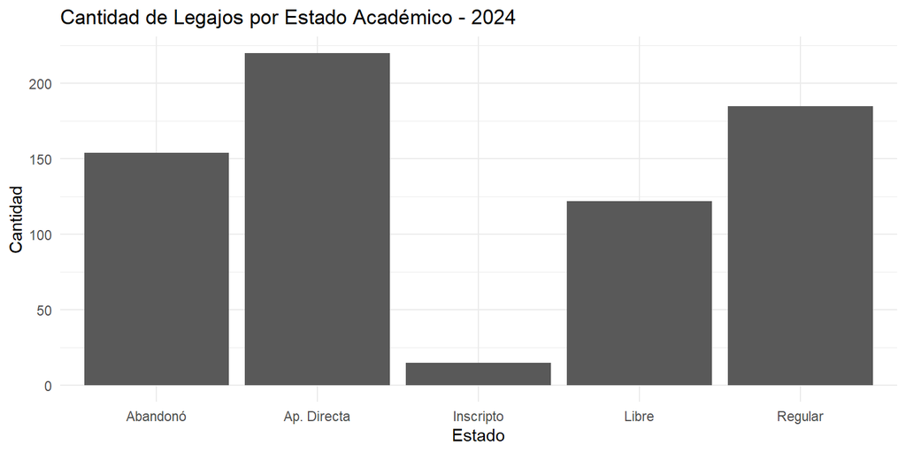

```r
# Gráfico
ggplot(estado_2024, aes(x = estado, y = total)) +
  geom_bar(stat = "identity") +
  theme_minimal() +
  labs(title = "Cantidad de Legajos por Estado Académico - 2024", x = "Estado", y = "Cantidad")
```

Este gráfico y tabla permiten visualizar la cantidad de estudiantes en cada estado académico, destacando posibles concentraciones en estados críticos (como libres o en riesgo de abandono).

## 4.2 Materias con Mayor Cantidad de Recursantes

Identificar las materias con mayor cantidad de recursantes es fundamental para comprender cuáles presentan mayor dificultad para los estudiantes y podrían requerir ajustes pedagógicos o metodológicos.

**Código**

```r
# Materias con más recursantes
recursantes_2024 <- data_2024 %>%
  filter(recursa == "Si") %>%
  group_by(nombre_materia) %>%
  summarise(total = n(), .groups = "drop") %>%
  arrange(desc(total))

# Tabla
kable(recursantes_2024, caption = "Materias con Más Recursantes - 2024") %>%
  kable_styling(full_width = FALSE)
```

Materias con Más Recursantes - 2024

| nombre_materia | total |
| --- | --- |
| Proyecto Final | 28 |
| Física II | 20 |
| Álgebra y Geometría Analítica | 20 |
| Física I | 19 |
| Investigación Operativa | 16 |
| Análisis Matemático I | 15 |
| Análisis Matemático II | 13 |
| Análisis Numérico y Cálculo Avanzado | 13 |
| Química General | 13 |
| Ciencia de los Materiales | 12 |
| Informática I | 12 |
| Informática II | 12 |
| Pensamiento Sistémico | 10 |
| Mecánica de los Fluidos | 8 |
| Evaluación de Proyectos | 7 |
| Inglés I | 7 |
| Probabilidad y Estadística | 7 |
| Termodinámica y Máquinas Térmicas | 6 |
| Inglés II | 5 |
| Comercialización | 4 |
| Comercio Exterior | 4 |
| Diseño de Producto | 4 |
| Sistemas de Representación | 4 |
| Costos y Presupuestos | 3 |
| Estática y Resistencia de Materiales | 3 |
| Legislación | 3 |
| Agilidad y Lider Coach (Elec.) | 2 |
| Contabilidad Estratégica (Elec.) | 2 |
| Economía de la Empresa | 2 |
| Electrotecnia y Máquinas Eléctricas | 2 |
| Estudio del Trabajo | 2 |
| Ingeniería en Calidad | 2 |
| Ingeniería y Sociedad | 2 |
| Planificación y Control de la Producción | 2 |
| Control de Gestión | 1 |
| Emprendimiento e Innovación (Elec.) | 1 |
| Instalaciones Industriales | 1 |
| Introducción a la Investigación Científica (Elec.) | 1 |
| Logística Industrial (Elec.) | 1 |
| Mecánica y Mecanismos | 1 |

**Código**

```r
# 10 materias con más recursantes
recursantes_top_10 <- recursantes_2024 %>%
  slice_max(order_by = total, n = 10)

# Tabla
kable(recursantes_top_10, caption = "Top 10 Materias con Más Recursantes - 2024") %>%
  kable_styling(full_width = FALSE)
```

| nombre_materia | total |
| --- | --- |
| Proyecto Final | 28 |
| Física II | 20 |
| Álgebra y Geometría Analítica | 20 |
| Física I | 19 |
| Investigación Operativa | 16 |
| Análisis Matemático I | 15 |
| Análisis Matemático II | 13 |
| Análisis Numérico y Cálculo Avanzado | 13 |
| Química General | 13 |
| Ciencia de los Materiales | 12 |
| Informática I | 12 |
| Informática II | 12 |

**Código**

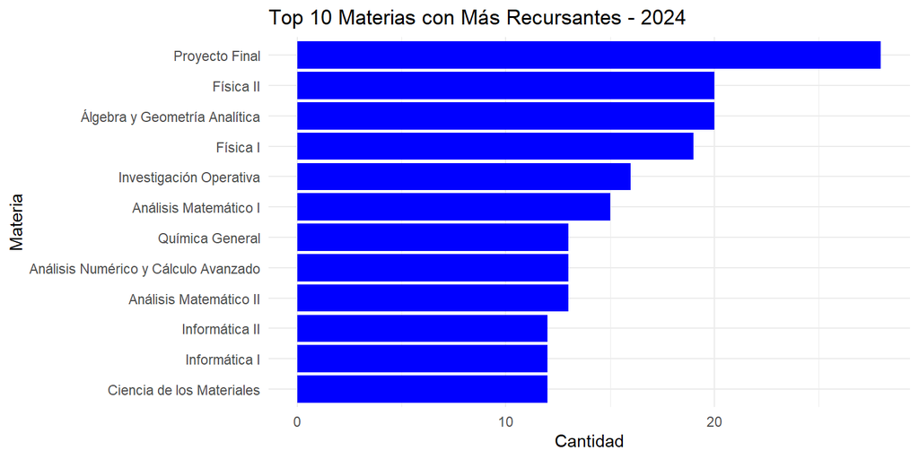

```r
# Gráfico para las 10 primeras
ggplot(recursantes_top_10, aes(x = reorder(nombre_materia, total), y = total)) +
  geom_bar(stat = "identity", fill = "blue") +
  coord_flip() +
  theme_minimal() +
  labs(
    title = "Top 10 Materias con Más Recursantes - 2024",
    x = "Materia",
    y = "Cantidad"
  )
```

Las materias con mayor cantidad de recursantes son un indicador clave para evaluar áreas curriculares que podrían requerir intervenciones. Esto incluye revisiones en el diseño de las evaluaciones o apoyo adicional para los estudiantes.

## 4.3 Desempeño de los Estudiantes Recursantes

Este punto esta orientado a las tutorias de cada especialidad donde hacen el seguimiento de los alumnos recursantes. Se analizó el desempeño de los estudiantes que recursaron y desaprobaron materias en 2024 para poder hacerle un seguimiento en el receso. Este grupo es particularmente relevante para entender barreras significativas en su progreso académico.

**Código**

```r
# Agrupar por materia
reprobados_por_materia <- data_2024 %>%
  filter(recursa == "Si" & aprobado == "No aprobado") %>%
  group_by(nombre_materia) %>%
  summarise(
    legajos = paste(legajo, collapse = ", "),
    total = n(),
    .groups = "drop"
  ) %>%
  arrange(desc(total))

# Tabla
kable(reprobados_por_materia, caption = "Materias con Legajos de Estudiantes que Reprobaron Tras Recursar - 2024") %>%
  kable_styling(bootstrap_options = c("striped", "hover", "condensed"), full_width = FALSE)
```

Materias con Legajos de Estudiantes que Reprobaron Tras Recursar - 2024

| nombre_materia | legajos | total |
| --- | --- | --- |
| Proyecto Final | 12141, 9788, 11250, 8528, 9832, 10865, 8616, 13307, 13997, 14013, 14019, 14029, 14059, 14065, 14593, 14678, 13660, 13657, 14011, 14125, 13308, 14393, 13649, 14105, 13680, 14569, 14662, 14064 | 28 |
| Álgebra y Geometría Analítica | 16674, 15866, 15710, 16137, 16547, 16569, 16622, 17130, 17159, 17164, 17185, 17193, 17173, 17175, 17165, 17264, 16601, 17162 | 18 |
| Física II | 12258, 15787, 15790, 13518, 15181, 15228, 15672, 15708, 15732, 15791, 15804, 15189, 16135, 15137, 15999, 15164, 14591 | 17 |
| Física I | 16674, 15883, 16137, 16547, 16569, 16622, 17130, 17159, 17164, 17185, 17193, 17173, 17264, 17257, 16601, 17162 | 16 |
| Investigación Operativa | 10245, 12825, 14060, 13221, 13229, 13254, 13485, 13628, 14991, 15104, 15171, 15223, 15616, 14021, 13708, 14647 | 16 |
| Informática I | 16569, 16674, 16137, 16547, 16622, 16670, 17159, 17185, 17173, 17175, 16601, 17162 | 12 |
| Química General | 16569, 15791, 16137, 16622, 17159, 17164, 17173, 17185, 17193, 17264, 17257, 16601 | 12 |
| Análisis Matemático I | 16137, 16622, 17159, 17164, 17173, 17185, 17193, 17257, 17162, 15164 | 10 |
| Análisis Matemático II | 12258, 14567, 15189, 15672, 15791, 15801, 15119, 15215, 15181, 15999 | 10 |
| Análisis Numérico y Cálculo Avanzado | 13485, 11685, 13316, 13485, 13628, 14987, 15223, 15616, 14113 | 9 |
| Ciencia de los Materiales | 14080, 14614, 15181, 15228, 15672, 15787, 16135, 15999, 13488 | 9 |
| Informática II | 12258, 13518, 14080, 14987, 15138, 15787, 15791, 15801, 15119 | 9 |
| Evaluación de Proyectos | 12239, 14100, 14602, 14660, 14759, 13604, 13254 | 7 |
| Pensamiento Sistémico | 16674, 16137, 16622, 16976, 17159, 17185, 17264 | 7 |
| Inglés I | 17159, 17185, 17193, 17257, 17165, 17264 | 6 |
| Probabilidad y Estadística | 15787, 14987, 14567, 15672, 16976, 16135 | 6 |
| Termodinámica y Máquinas Térmicas | 9791, 13316, 11908, 13316, 15184, 15933 | 6 |
| Mecánica de los Fluidos | 13316, 13316, 13628, 15616, 14577 | 5 |
| Inglés II | 12692, 15181, 15732, 15616 | 4 |
| Comercio Exterior | 7824, 11258, 11905 | 3 |
| Comercialización | 13316, 13316 | 2 |
| Costos y Presupuestos | 12013, 13316 | 2 |
| Estática y Resistencia de Materiales | 12825, 13316 | 2 |
| Planificación y Control de la Producción | 14602, 13485 | 2 |
| Agilidad y Lider Coach (Elec.) | 13229 | 1 |
| Contabilidad Estratégica (Elec.) | 13229 | 1 |
| Economía de la Empresa | 13316 | 1 |
| Electrotecnia y Máquinas Eléctricas | 13316 | 1 |
| Estudio del Trabajo | 13316 | 1 |
| Ingeniería en Calidad | 14602 | 1 |
| Instalaciones Industriales | 12833 | 1 |
| Introducción a la Investigación Científica (Elec.) | 14393 | 1 |
| Legislación | 14127 | 1 |
| Mecánica y Mecanismos | 15171 | 1 |
| Sistemas de Representación | 17185 | 1 |

# 5 Conclusión General del Análisis Académico

El análisis realizado proporciona una visión integral sobre el estado académico de los estudiantes a lo largo de los años, con un enfoque específico en el año en curso.

A continuación, se destacan los puntos más importantes a ser analizados por la especialidad:

1. *Distribución General y Estados Académicos*

   La distribución de estudiantes en diferentes estados académicos (como en curso, recursantes y egresados) permite identificar patrones clave en el progreso académico de la especialidad.

   *Importancia:*
   - Los estudiantes en estados críticos representan una prioridad para la institución, ya que pueden impactar las tasas de retención y finalización.
   - Se recomienda implementar programas específicos de seguimiento y apoyo para estos grupos.
2. *Ingresantes y Graduados por Año*

   El análisis sobre ingresantes y graduados proporciona una evaluación de la eficiencia académica a lo largo de los años:
   - Ingresantes: Las tendencias anuales reflejan el atractivo de la especialidad y posibles fluctuaciones debido a factores externos (como políticas de admisión o promoción).
   - Graduados: Un aumento en la cantidad de graduados en los últimos años podría indicar mejoras en la gestión académica o en el acompañamiento estudiantil.

   *Importancia:*

   Identificar las cohortes con menor cantidad de graduados puede ayudar a diseñar estrategias específicas para mejorar la eficiencia académica.
3. *Materias con Mayor Dificultad*

   El análisis de materias con mayor cantidad de recursantes en 2024 identifica áreas curriculares que presentan desafíos significativos para los estudiantes. Estas materias pueden tener características particulares que dificulten su aprobación, como contenidos complejos, evaluaciones exigentes o métodos pedagógicos que no se alinean con las necesidades del estudiantado.

   *Importancia:*
   - Revisar los programas y métodos de enseñanza en estas materias.
   - Implementar recursos adicionales, como tutorías, guías prácticas o espacios de consulta.

   4. *Desempeño de los Estudiantes Recursantes*

   El grupo de estudiantes que recursaron y reprobaron representa una población especialmente vulnerable dentro del sistema académico. Estos casos reflejan barreras significativas que afectan su progreso y requieren atención prioritaria.

   *Importancia:*
   - Diseñar intervenciones específicas para estudiantes que recursan repetidamente, como diagnósticos tempranos, acompañamiento pedagógico o acceso a materiales de apoyo.
   - Evaluar si existen diferencias significativas entre grupos (como género o tipo de formación secundaria) para abordar desigualdades.

   5. *Inclusión y Diversidad*

   El análisis de la distribución por género destaca el compromiso de la institución con políticas de inclusión y equidad. Monitorear las proporciones de género a lo largo de los años es esencial para garantizar que estas políticas tengan un impacto positivo.